# Ejemplo VAR(2)

Javier López

7/5/2020

## **Ejercicio Simulación $VAR(2)$**

Vamos a simular un proceso $VAR(2)$ con la siguiente estructura:
$$\begin{bmatrix}
Y_{1t}\\
Y_{2t}
\end{bmatrix} =
\begin{bmatrix}
5.0\\
10.0
\end{bmatrix} +
\begin{bmatrix}
0.5 & 0.2 \\
-0.2 & -0.5
\end{bmatrix}
\begin{bmatrix}
Y_{1,t-1}\\
Y_{2,t-1}
\end{bmatrix} +
\begin{bmatrix}
-0.3 & -0.7 \\
-0.1 & 0.3
\end{bmatrix}
\begin{bmatrix}
Y_{1,t-2}\\
Y_{2,t-2}
\end{bmatrix} +
\begin{bmatrix}
a_{1t}\\
a_{2t}
\end{bmatrix}$$

```r
#################################################################
#################################################################
#####   Programa Clase 7 - Series de Tiempo                  ####
#####   Fecha de creación: 20200605                          ####
#####   Fecha de última edición: 20200605                    ####
#####   Autor: Edgar Javier López Moreno                     ####
#####   E-mail: edgar.lopez@libertadores.edu.co              ####
#################################################################
#################################################################

rm(list = ls())

#################################################################
#####                   Librerias utilizadas                #####
#################################################################

library(dse)
library(vars)
library(fUnitRoots)
```

```r
#################################################################
#####                   Ejecución Programa                  #####
#################################################################

Apoly <- array(c(1.0, -0.5, 0.3, 0, 0.2, 0.1, 0, -0.2, 0.7, 1, 0.5, -0.3),
               c(3, 2, 2))
B   <- diag(2)
TRD <- c(5, 10)
Apoly
```

```
## , , 1
##
##      [,1] [,2]
## [1,]  1.0  0.0
## [2,] -0.5  0.2
## [3,]  0.3  0.1
##
## , , 2
##
##      [,1] [,2]
## [1,]  0.0  1.0
## [2,] -0.2  0.5
## [3,]  0.7 -0.3
```

```r
B
```

```
##      [,1] [,2]
## [1,]    1    0
## [2,]    0    1
```

```r
TRD
```

```
## [1]  5 10
```

Donde Apoly son las matrices $\phi_1$ y $\phi_2$, TRD es la media y B es la matriz de varianzas y covarianzas

```r
### Generando el modelo VAR(2)
var2 <- ARMA(A = Apoly, B = B, TREND = TRD)
var2
```

```
## TREND=   5 10
## A(L) =
## 1-0.5L1+0.3L2    0-0.2L1+0.7L2
## 0+0.2L1+0.1L2    1+0.5L1-0.3L2
##
## B(L) =
## 1    0
## 0    1
```

```r
### Simulación de 500 observaciones
set.seed(12145)
varsim <- simulate(var2, sampleT = 500,
                   noise = list(w = matrix(rnorm(1000), nrow = 500, ncol = 2)),
                   rng = list(seed = c (123456)))
vardat <- matrix(varsim$output, nrow = 500 , ncol = 2)
colnames(vardat) <- c('y1', 'y2')
head(vardat)
```

```
##             y1       y2
## [1,]  5.755609 9.793441
## [2,] 10.732017 4.042320
## [3,]  1.753259 8.902016
## [4,]  3.160088 5.852272
## [5,]  1.127852 8.504802
## [6,]  2.475758 8.108022
```

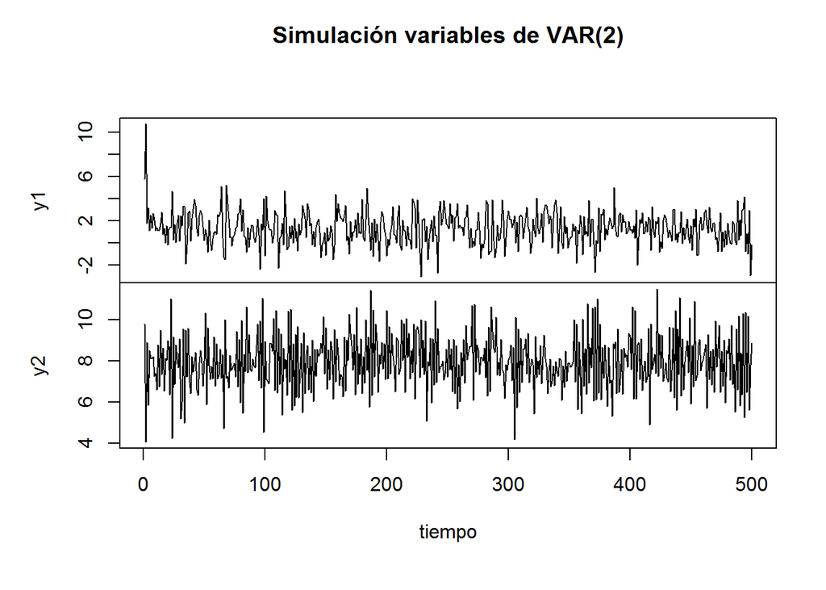

```r
plot.ts(vardat, main = 'Simulación variables de VAR(2)', xlab = 'tiempo')
```

### **Especificación**

Siguiendo la metodología de Box-Jenkins, realizamos la especificación del modelo apartir de los criterios. Utilizamos la función *VARselect* de la librería *vars* donde el orden es $p=2$.

```r
######################
### Especificación ###
######################

infocrit <- VARselect(vardat, lag.max = 3 , type = 'const')
infocrit
```

```
## $selection
## AIC(n)  HQ(n)  SC(n) FPE(n)
##      2      2      2      2
##
## $criteria
##                1         2         3
## AIC(n) 0.6239280 0.1133059 0.1242073
## HQ(n)  0.6438701 0.1465427 0.1707388
## SC(n)  0.6747359 0.1979858 0.2427592
## FPE(n) 1.8662448 1.1199760 1.1322548
```

```r
##################
### Estimación ###
##################

varsimest <- VAR(vardat, p = 2, type = 'const', season = NULL, exogen = NULL)
varsimest
```

```
##
## VAR Estimation Results:
## =======================
##
## Estimated coefficients for equation y1:
## =======================================
## Call:
## y1 = y1.l1 + y2.l1 + y1.l2 + y2.l2 + const
##
##      y1.l1      y2.l1      y1.l2      y2.l2      const
##  0.5067092  0.2409921 -0.3328615 -0.7246132  4.9349642
##
##
## Estimated coefficients for equation y2:
## =======================================
## Call:
## y2 = y1.l1 + y2.l1 + y1.l2 + y2.l2 + const
##
##      y1.l1      y2.l1      y1.l2      y2.l2      const
## -0.1909799 -0.4872764 -0.1062556  0.2662352 10.1384630
```

```r
### Raices
roots <- roots(varsimest)
roots
```

```
## [1] 0.7874630 0.6058819 0.6058819 0.5729147
```

Dado que los valores propios son menores que uno, podemos decir que la serie es estacionaria. Luego, tenemos que las estimaciones de los parametros del modelo $VAR(2)$ son:

$$\begin{bmatrix}
Y_{1t}\\
Y_{2t}
\end{bmatrix} =
\begin{bmatrix}
4.93\\
10.13
\end{bmatrix} +
\begin{bmatrix}
0.50 & 0.24 \\
-0.19 & -0.48
\end{bmatrix}
\begin{bmatrix}
Y_{1,t-1}\\
Y_{2,t-1}
\end{bmatrix} +
\begin{bmatrix}
-0.33 & -0.72 \\
-0.10 & 0.26
\end{bmatrix}
\begin{bmatrix}
Y_{1,t-2}\\
Y_{2,t-2}
\end{bmatrix}$$

### **Diagnóstico del modelo**

Siguiendo la metodología de Box-Jenkins, realizamos la especificación del modelo apartir de los criterios. Utilizamos la función *VARselect* de la librería *vars* donde el orden es $p=2$.

#### Correlación - Test de Portmanteau

Al igual que en el caso univariado, el interés está en revisar la correlación de los residuales, luego planteamos la siguiente hipótesis:
$$\begin{align*}
H_0 &: R_1 = R_2 = ... = R_m = \mathbf{0}\\
H_a &: R_j \neq \mathbf{0} \;\ para \;\ 1 \leq j \leq m
\end{align*}$$
donde $R_l$ es la matriz de correlación cruzada del rezago $l$.

Luego la estadística de Portmanteau
$$Q_k(m)=n^2 \sum_{l=1}^m \dfrac{1}{n-l}tr\left( \hat{C}_l^´ \hat{C}_0^{-1} \hat{C}_l \hat{C}_0^{-1} \right)$$

```r
###################
### Diagnóstico ###
###################

### Testeando correlación
var2c.serial <- serial.test(varsimest, lags.pt = 16, type = 'PT.asymptotic')

var2c.serial
```

```
##
##  Portmanteau Test (asymptotic)
##
## data:  Residuals of VAR object varsimest
## Chi-squared = 60.545, df = 56, p-value = 0.3152
```

#### Heterocedasticidad - Test de Arch

El test multivariado ARCH-LM está basado sobre la siguiente regresion:
$$vec(\mathbf{\hat{a_{t}}}\mathbf{\hat{a}_{t}}^´) = \beta_0 + B_1vec(\mathbf{\hat{a_{t-1}}}\mathbf{\hat{a}_{t-1}}^´) + ... + B_qvec(\mathbf{\hat{a_{t-q}}}\mathbf{\hat{a}_{t-q}}^´) + \mathbf{e_t}$$
Donde se plantea la siguiente hipotesis:
$$\begin{align*}
H_0&: B_1 = B_2 = ... = B_q = 0\\
H_a&: B_1 \neq 0 \cap B_2 \neq 0 \cap ... \cap B_q \neq 0
\end{align*}$$
El estadístico está dado por:
$$VARCH_{LM}(q) = \dfrac{1}{2}nk(k+1)\left( 1-\dfrac{2}{n(n1)}tr(\hat{\Sigma_0}\hat{\Sigma_0}^{-1}) \right)$$
Que se distribuye $\chi^2$ con $\frac{qk^2(k+1)^2}{4}$ grados de libertad.

```r
### Testeando heteroscedaticidad
var2c.arch <- arch.test(varsimest, lags.multi = 5, multivariate.only = TRUE)
var2c.arch
```

```
##
##  ARCH (multivariate)
##
## data:  Residuals of VAR object varsimest
## Chi-squared = 42.62, df = 45, p-value = 0.5733
```

#### Normalidad - Test Jarque-Bera

La versión univariada del test Jarque-Bera es aplicado a los residuales de cada ecuación. En la versión multivaraida este test puede ser calcualdo usando los residuales que son estandarizados por la descomposción de Choleski de la matriz de varianzas y covarianzas.

```r
### Testeando normalidad
var2c.norm <- normality.test(varsimest, multivariate.only = TRUE)
var2c.norm
```

```
## $JB
##
##  JB-Test (multivariate)
##
## data:  Residuals of VAR object varsimest
## Chi-squared = 1.4116, df = 4, p-value = 0.8422
##
##
## $Skewness
##
##  Skewness only (multivariate)
##
## data:  Residuals of VAR object varsimest
## Chi-squared = 0.13256, df = 2, p-value = 0.9359
##
##
## $Kurtosis
##
##  Kurtosis only (multivariate)
##
## data:  Residuals of VAR object varsimest
## Chi-squared = 1.279, df = 2, p-value = 0.5276
```

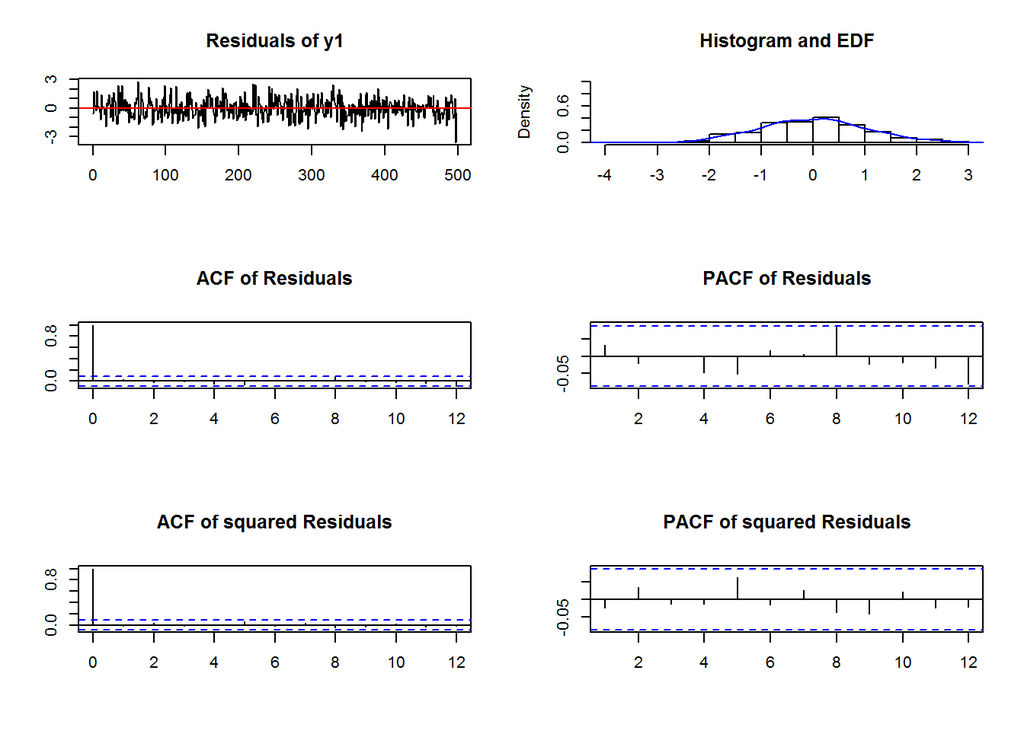

```r
plot(var2c.norm, names = 'y1')
```

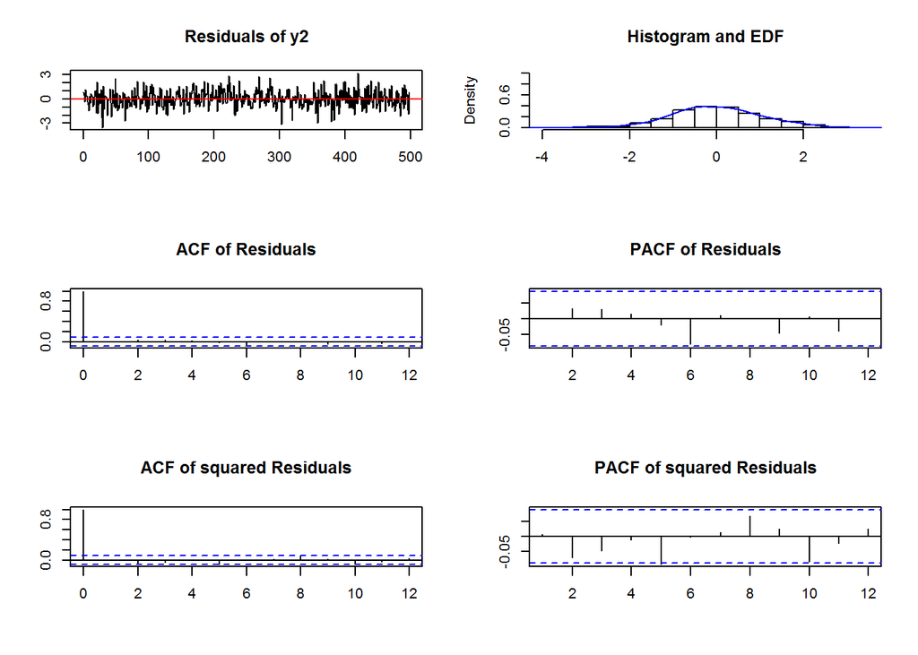

```r
plot(var2c.norm, names = 'y2')
```

#### **Analisis de Causalidad**

Podemos reescribir $VAR(p)$ como:
$$\begin{bmatrix}
Y_{1t}\\
Y_{2t}
\end{bmatrix} =
\sum_{i=1}^{p}
\begin{bmatrix}
\alpha_{11,i} & \alpha_{12,i} \\
\alpha_{21,i} & \alpha_{22,i}
\end{bmatrix}
\begin{bmatrix}
Y_{1,t-1}\\
Y_{2,t-1}
\end{bmatrix} +
CD_t +
\begin{bmatrix}
a_{1t}\\
a_{2t}
\end{bmatrix}$$
Luego el test de causalidad de Granger tiene $H_0: Y_{2t}$ no tienen causalidad de Granger sobre $Y_{1t}$, definida como $\alpha_{12,i} = 0$ para $i=1,2,...,p$
Para el test de causalidad no instantanea tiene $H_0:C_\sigma=0$, donde $C_\sigma$ es una matriz de varianzas y covarianzas de $a_{1t}$ y $a_{2t}$.

```r
## Test de Causalidad
var.causal <- causality(varsimest, cause = 'y2')
var.causal
```

```
## $Granger
##
##  Granger causality H0: y2 do not Granger-cause y1
##
## data:  VAR object varsimest
## F-Test = 245.41, df1 = 2, df2 = 986, p-value < 2.2e-16
##
##
## $Instant
##
##  H0: No instantaneous causality between: y2 and y1
##
## data:  VAR object varsimest
## Chi-squared = 0.11532, df = 1, p-value = 0.7342
```

Luego el test de Granger me indica que se rechaza $H_0$, lo cual significa que existe causalida de $Y_{2t}$ sobre $Y_{1t}$.

### **Pronóstico**

```r
##################
### Pronóstico ###
##################

predictions <- predict(varsimest, n.ahead = 10, ci = 0.95)
predictions
```

```
## $y1
##            fcst      lower    upper       CI
##  [1,] 2.2988569  0.3256963 4.272018 1.973161
##  [2,] 1.7130701 -0.5561086 3.982249 2.269179
##  [3,] 1.0158785 -1.6990390 3.730796 2.714917
##  [4,] 0.9187662 -1.8064372 3.643970 2.725203
##  [5,] 1.3418321 -1.4002854 4.083950 2.742117
##  [6,] 1.3685073 -1.4022554 4.139270 2.770763
##  [7,] 1.3282602 -1.4568190 4.113339 2.785079
##  [8,] 1.2369970 -1.5500875 4.024082 2.787084
##  [9,] 1.2949688 -1.4960911 4.086029 2.791060
## [10,] 1.2956788 -1.4980854 4.089443 2.793764
##
## $y2
##           fcst    lower    upper       CI
##  [1,] 8.234088 6.196068 10.27211 2.038020
##  [2,] 8.069210 5.768531 10.36989 2.300679
##  [3,] 7.827303 5.336526 10.31808 2.490777
##  [4,] 8.096675 5.557241 10.63611 2.539434
##  [5,] 7.993640 5.375273 10.61201 2.618366
##  [6,] 8.045084 5.397621 10.69255 2.647464
##  [7,] 7.942537 5.275424 10.60965 2.667113
##  [8,] 8.011054 5.332637 10.68947 2.678417
##  [9,] 7.972072 5.284949 10.65919 2.687123
## [10,] 8.007935 5.316470 10.69940 2.691465
```

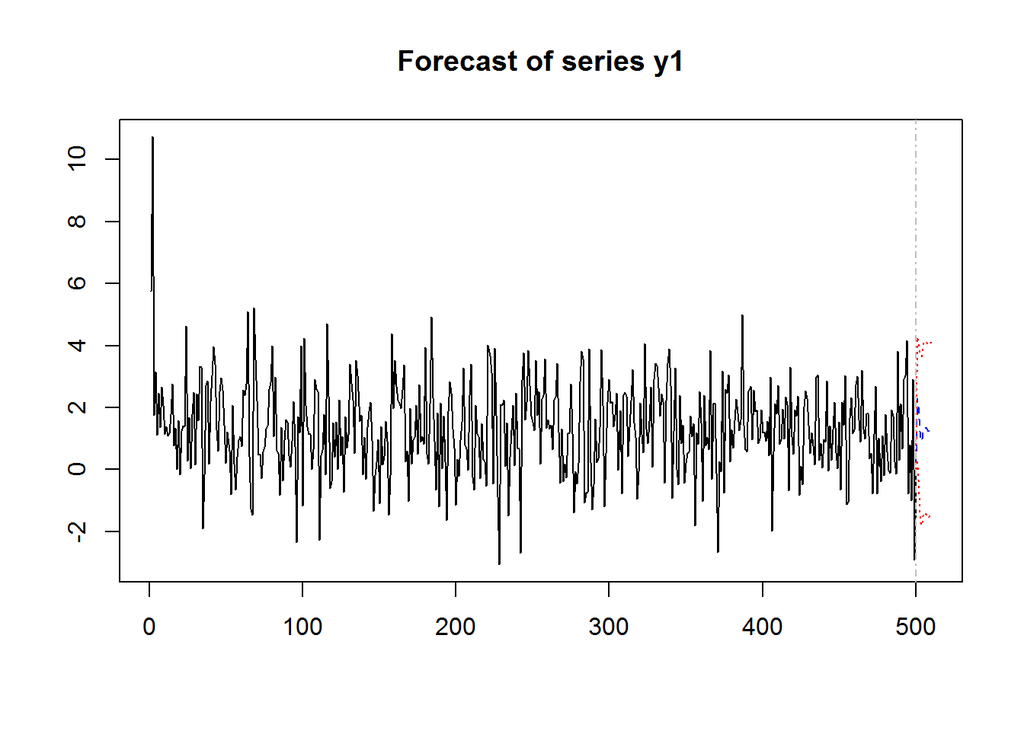

```r
plot(predictions, names = 'y1')
```

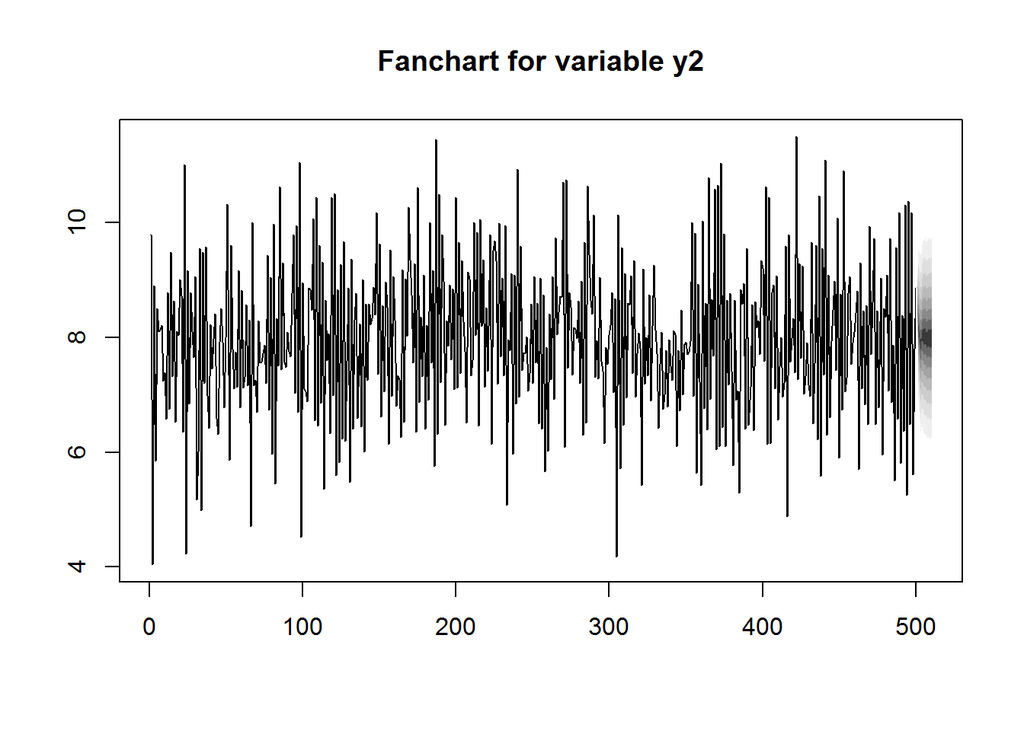

```r
#plot(predictions, names = 'y2')
#fanchart(predictions , names = 'y1')
fanchart(predictions , names = 'y2')
```

#### **Funciones de respuesta de impulso**

Previamente habiamos visto la causalidad de las variables, pero no habiamos podido cuantificar el impacto del impulso de la variable sobre la variable respuesta a traves del tiempo. El analisis de impulso de respuesta es usado para investigar ese tipo de interacciones dinamicas entre las variables. Estas se pueden interpretar como la respuesta esperada de la variable $Y_{i,t+s}$ a un cambio en la variable $Y_{j,t}$. Estos efectos pueden ser acumulados a travez del tiempo $s=1,2,...$, por lo tanto, uno obtendría el impacto acumulado del cambio de una unidad en l variable $j$ sobre la variable $i$ en el tiempo $s$.

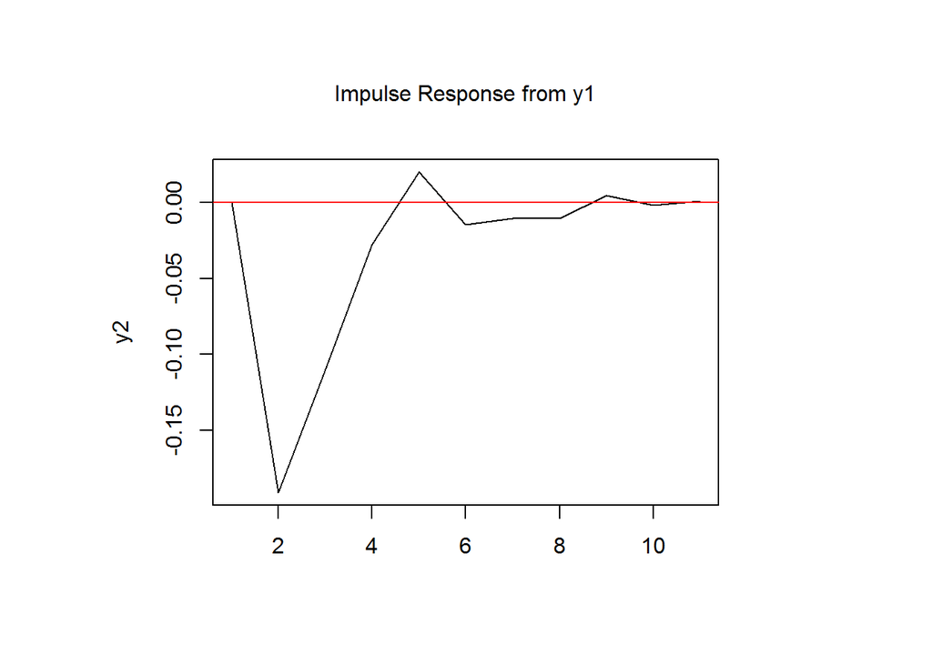

```r
## Analisis de impulso
irf.y1 <- irf(varsimest, impulse = 'y1',
              response = 'y2', n.ahead = 10,
              ortho = FALSE, cumulative = FALSE,
              boot = FALSE, seed = 12345)
plot(irf.y1)
```

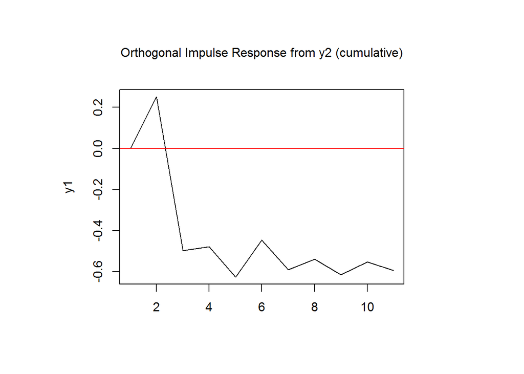

```r
irf.y2 <- irf(varsimest, impulse = 'y2',
              response = 'y1', n.ahead = 10,
              ortho = TRUE, cumulative = TRUE,
              boot = FALSE, seed = 12345)
plot(irf.y2)
```

#### **Pronóstico de la descomposición del error de la varianza**

Este analiza la contribución de la variable $j$ al $h-ésimo$ pronóstico de la varianza del error de la variable $k$.

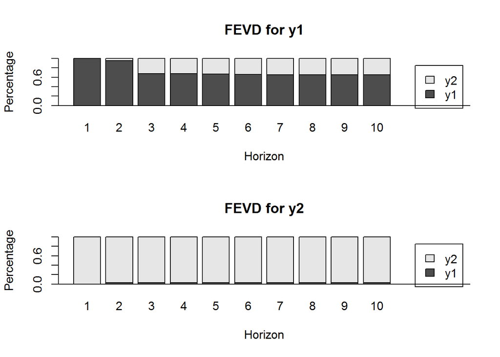

```r
## Pronostico descomosición de la varianza
fevd.var2 <- fevd(varsimest, n.ahead = 10)
plot(fevd.var2, addbars = 2)
```

### **Ejemplo Practico**

Ejemplo del PIB de UK, Canadá y USA.

```r
#################################################################
#################################################################
#####   Programa Clase 6 - Series de Tiempo                  ####
#####   Fecha de creación: 20200430                          ####
#####   Fecha de última edición: 20200430                    ####
#####   Autor: Edgar Javier López Moreno                     ####
#####   E-mail: edgar.lopez@libertadores.edu.co              ####
#################################################################
#################################################################

rm(list = ls())

#################################################################
#####                   Librerias utilizadas                #####
#################################################################

library(dse)
library(vars)
library(fUnitRoots)
library(readxl)

#################################################################
#####                   Sistema de carpetas                 #####
#################################################################

inpath  <- "D:/PERSONAL/6. EDUCACIÓN/1-LIBERTADORES/1-SERIES DE TIEMPO/inpath/"
outpath <- "D:/PERSONAL/6. EDUCACIÓN/1-LIBERTADORES/1-SERIES DE TIEMPO/outpath/"

#################################################################
#####                   Carga de información                #####
#################################################################

GDP_UKCAUS <- read_excel(paste(inpath,"GDP UK CA US.xlsx", sep = ""))
```

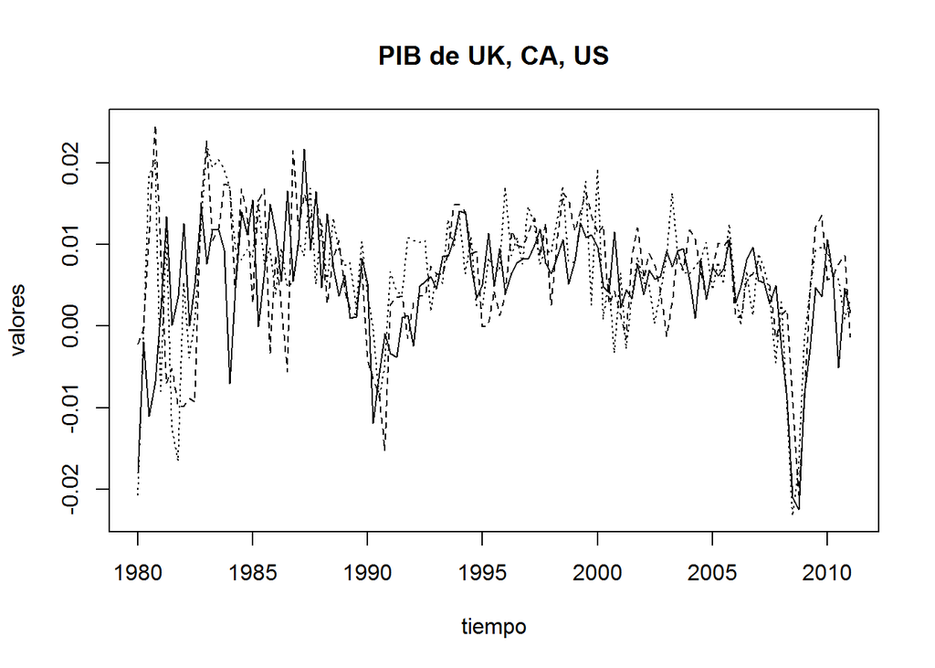

```r
#################################################################
#####                   Ejecución Programa                  #####
#################################################################

gdp<- log(GDP_UKCAUS[,3:5])
uk <- ts(diff(gdp$uk), start = c(1980, 1), frequency = 4)
ca <- ts(diff(gdp$ca), start = c(1980, 1), frequency = 4)
us <- ts(diff(gdp$us), start = c(1980, 1), frequency = 4)
gdp.ret <- cbind(uk,ca,us)*100

ts.plot(uk, ca, us, main = 'PIB de UK, CA, US',
        gpars = list(xlab = "tiempo", ylab = "valores", lty = c(1:3)))
```

```r
######################
### Especificación ###
######################

info.crit <- VARselect(gdp.ret, lag.max = 3 , type = 'const')
info.crit
```

```
## $selection
## AIC(n)  HQ(n)  SC(n) FPE(n)
##      1      1      1      1
##
## $criteria
##                 1           2           3
## AIC(n) -3.5343318 -3.53413189 -3.52559052
## HQ(n)  -3.4223083 -3.33809060 -3.24553153
## SC(n)  -3.2585265 -3.05147253 -2.83607715
## FPE(n)  0.0291803  0.02919513  0.02946699
```

```r
##################
### Estimación ###
##################

var.sim.est <- VAR(gdp.ret, p = 2, type = 'const', season = NULL, exogen = NULL)
var.sim.est
```

```
##
## VAR Estimation Results:
## =======================
##
## Estimated coefficients for equation uk:
## =======================================
## Call:
## uk = uk.l1 + ca.l1 + us.l1 + uk.l2 + ca.l2 + us.l2 + const
##
##      uk.l1      ca.l1      us.l1      uk.l2      ca.l2      us.l2
## 0.39306691 0.10310572 0.05213660 0.05660120 0.10552241 0.01889462
##      const
## 0.12581630
##
##
## Estimated coefficients for equation ca:
## =======================================
## Call:
## ca = uk.l1 + ca.l1 + us.l1 + uk.l2 + ca.l2 + us.l2 + const
##
##        uk.l1        ca.l1        us.l1        uk.l2        ca.l2
##  0.351313628  0.338141505  0.469093555 -0.191350134 -0.174833458
##        us.l2        const
## -0.008677767  0.123158083
##
##
## Estimated coefficients for equation us:
## =======================================
## Call:
## us = uk.l1 + ca.l1 + us.l1 + uk.l2 + ca.l2 + us.l2 + const
##
##       uk.l1       ca.l1       us.l1       uk.l2       ca.l2       us.l2
##  0.49069776  0.24000097  0.23564221 -0.31195550 -0.13117863  0.08531363
##       const
##  0.28955814
```

```r
### Raices
roots <- roots(var.sim.est)
roots
```

```
## [1] 0.61357818 0.61357818 0.35595587 0.33210353 0.33210353 0.03676301
```

```r
###################
### Diagnóstico ###
###################

### Testeando correlación
var2c.serial <- serial.test(var.sim.est, lags.pt = 16, type = 'PT.asymptotic')

var2c.serial
```

```
##
##  Portmanteau Test (asymptotic)
##
## data:  Residuals of VAR object var.sim.est
## Chi-squared = 124.51, df = 126, p-value = 0.5207
```

```r
### Testeando heteroscedaticidad
var2c.arch <- arch.test(var.sim.est, lags.multi = 5, multivariate.only = TRUE)
var2c.arch
```

```
##
##  ARCH (multivariate)
##
## data:  Residuals of VAR object var.sim.est
## Chi-squared = 275.77, df = 180, p-value = 5.661e-06
```

```r
### Testeando normalidad
var2c.norm <- normality.test(var.sim.est, multivariate.only = TRUE)
var2c.norm
```

```
## $JB
##
##  JB-Test (multivariate)
##
## data:  Residuals of VAR object var.sim.est
## Chi-squared = 44.251, df = 6, p-value = 6.592e-08
##
##
## $Skewness
##
##  Skewness only (multivariate)
##
## data:  Residuals of VAR object var.sim.est
## Chi-squared = 17.229, df = 3, p-value = 0.000634
##
##
## $Kurtosis
##
##  Kurtosis only (multivariate)
##
## data:  Residuals of VAR object var.sim.est
## Chi-squared = 27.021, df = 3, p-value = 5.827e-06
```

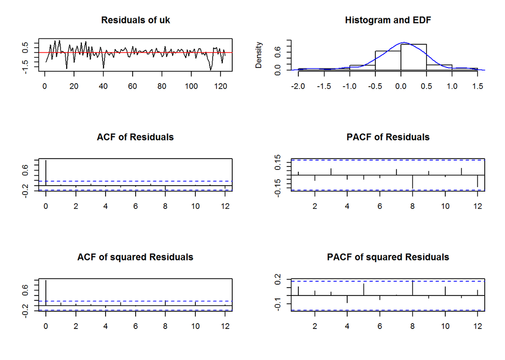

```r
plot(var2c.norm, names = 'uk')
```

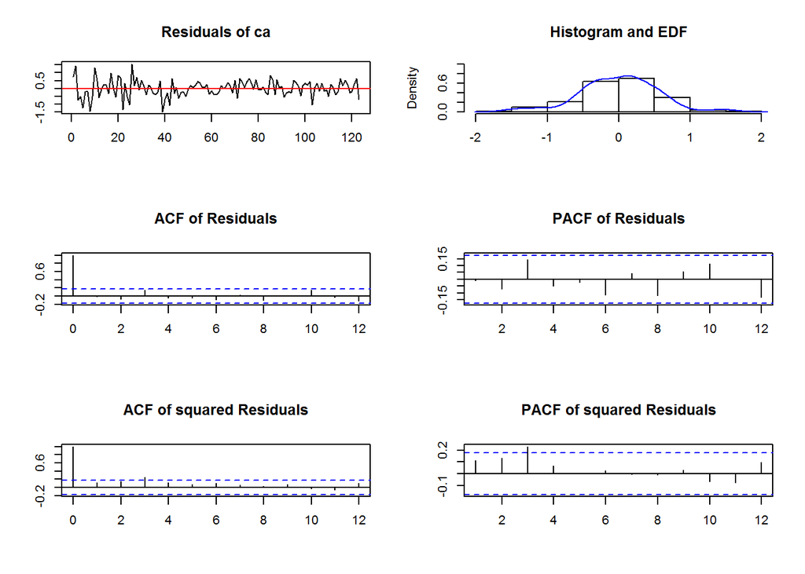

```r
plot(var2c.norm, names = 'ca')
```

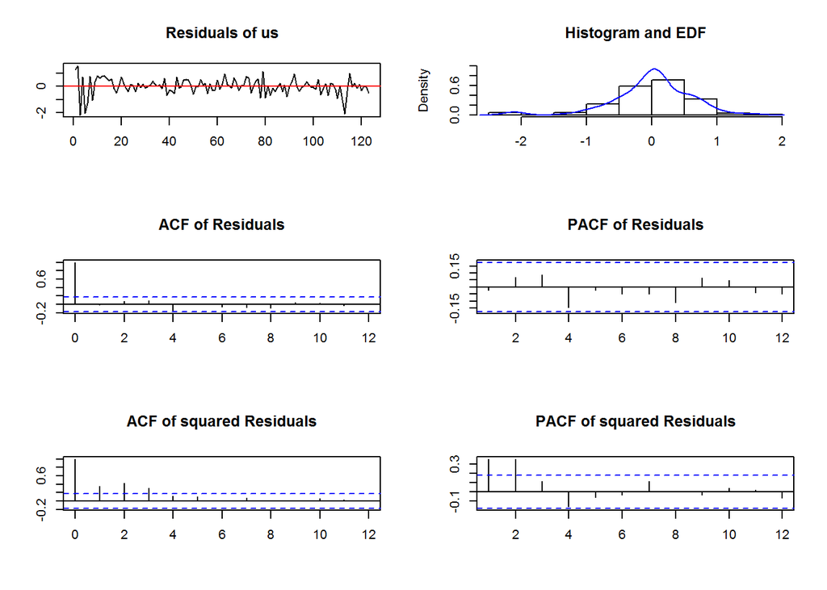

```r
plot(var2c.norm, names = 'us')
```

```r
## Test de Causalidad
var.causal.uk <- causality(var.sim.est, cause = 'uk')
var.causal.uk
```

```
## $Granger
##
##  Granger causality H0: uk do not Granger-cause ca us
##
## data:  VAR object var.sim.est
## F-Test = 6.7486, df1 = 4, df2 = 348, p-value = 3.06e-05
##
##
## $Instant
##
##  H0: No instantaneous causality between: uk and ca us
##
## data:  VAR object var.sim.est
## Chi-squared = 6.4042, df = 2, p-value = 0.04068
```

```r
var.causal.ca <- causality(var.sim.est, cause = 'ca')
var.causal.ca
```

```
## $Granger
##
##  Granger causality H0: ca do not Granger-cause uk us
##
## data:  VAR object var.sim.est
## F-Test = 2.1921, df1 = 4, df2 = 348, p-value = 0.06948
##
##
## $Instant
##
##  H0: No instantaneous causality between: ca and uk us
##
## data:  VAR object var.sim.est
## Chi-squared = 19.379, df = 2, p-value = 6.194e-05
```

```r
var.causal.us <- causality(var.sim.est, cause = 'us')
var.causal.us
```

```
## $Granger
##
##  Granger causality H0: us do not Granger-cause uk ca
##
## data:  VAR object var.sim.est
## F-Test = 6.4496, df1 = 4, df2 = 348, p-value = 5.13e-05
##
##
## $Instant
##
##  H0: No instantaneous causality between: us and uk ca
##
## data:  VAR object var.sim.est
## Chi-squared = 22.589, df = 2, p-value = 1.244e-05
```

```r
##################
### Pronóstico ###
##################

predictions <- predict(var.sim.est, n.ahead = 10, ci = 0.95)
predictions
```

```
## $uk
##            fcst      lower    upper       CI
##  [1,] 0.3128842 -0.7597163 1.385485 1.072600
##  [2,] 0.2646807 -0.9066793 1.436041 1.171360
##  [3,] 0.3143133 -0.9373647 1.565991 1.251678
##  [4,] 0.3838834 -0.9247663 1.692533 1.308650
##  [5,] 0.4411983 -0.8966127 1.779009 1.337811
##  [6,] 0.4798574 -0.8707378 1.830452 1.350595
##  [7,] 0.5067975 -0.8491957 1.862791 1.355993
##  [8,] 0.5247099 -0.8334297 1.882849 1.358140
##  [9,] 0.5360814 -0.8228448 1.895008 1.358926
## [10,] 0.5429319 -0.8162592 1.902123 1.359191
##
## $ca
##             fcst      lower    upper       CI
```

[output cut: 23 more lines]

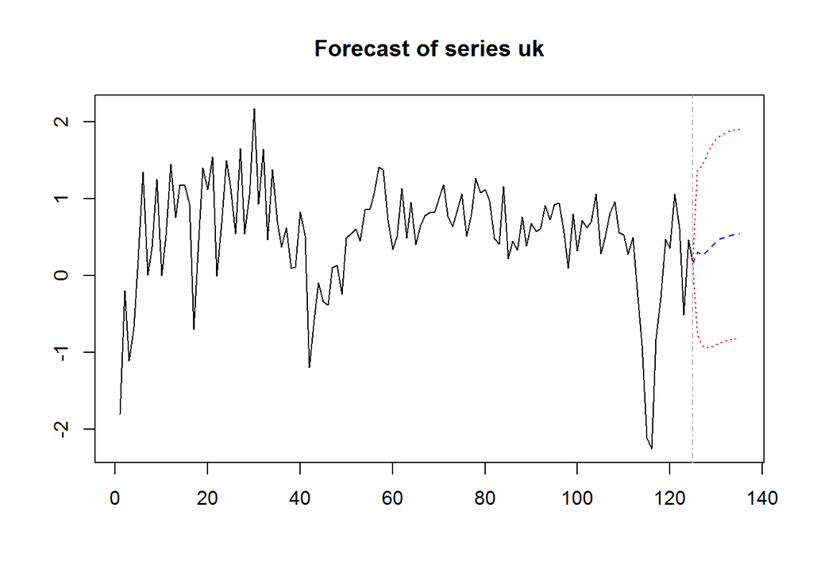

```r
plot(predictions, names = 'uk')
```

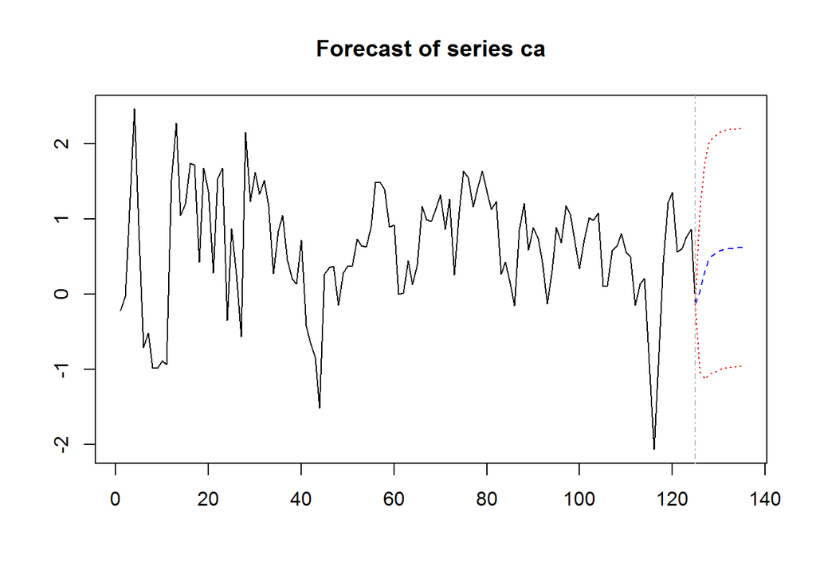

```r
plot(predictions, names = 'ca')
```

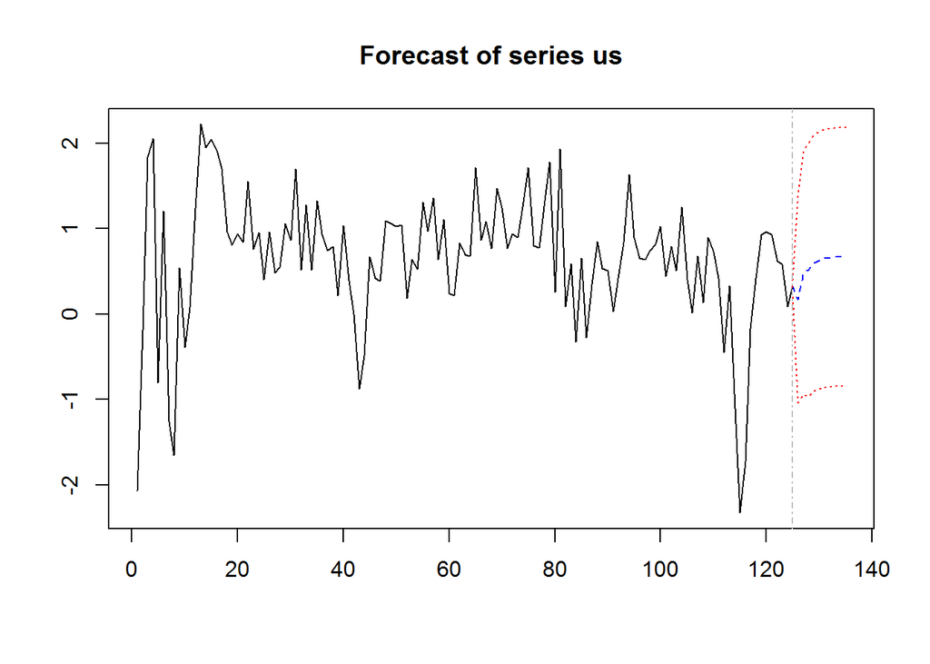

```r
plot(predictions, names = 'us')
```

```r
#plot(predictions, names = 'y2')
#fanchart(predictions , names = 'y1')
#fanchart(predictions , names = 'y2')
```

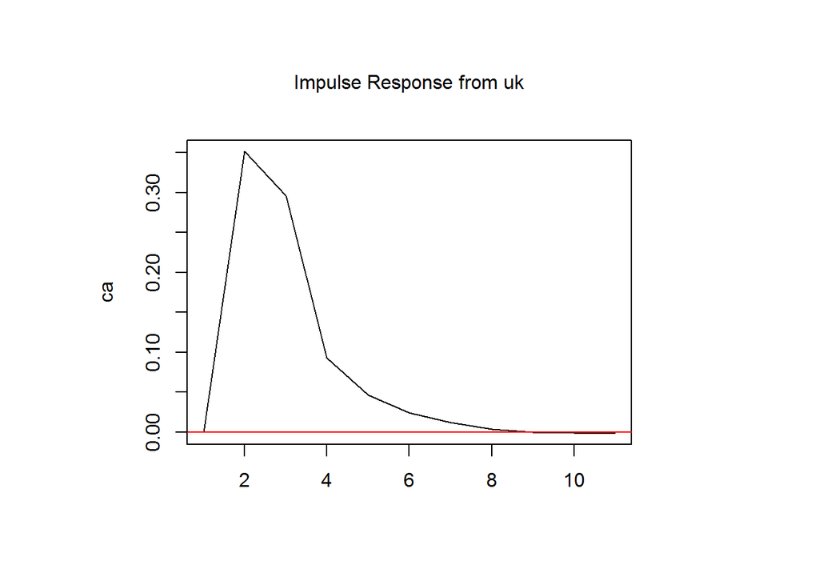

```r
## Analisis de impulso
irf.y12 <- irf(var.sim.est, impulse = 'uk',
              response = 'ca', n.ahead = 10,
              ortho = FALSE, cumulative = FALSE,
              boot = FALSE, seed = 12345)
plot(irf.y12)
```

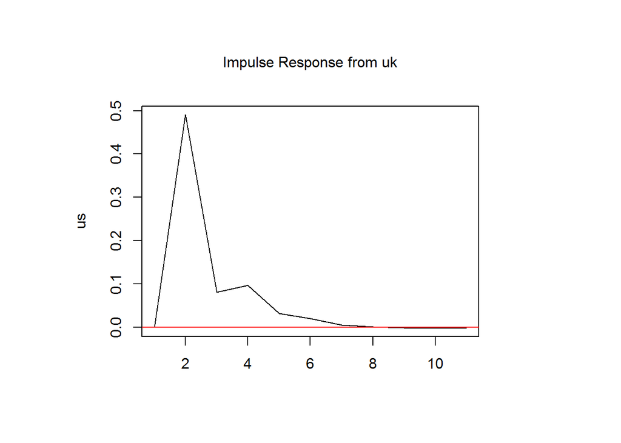

```r
irf.y13 <- irf(var.sim.est, impulse = 'uk',
              response = 'us', n.ahead = 10,
              ortho = FALSE, cumulative = FALSE,
              boot = FALSE, seed = 12345)
plot(irf.y13)
```

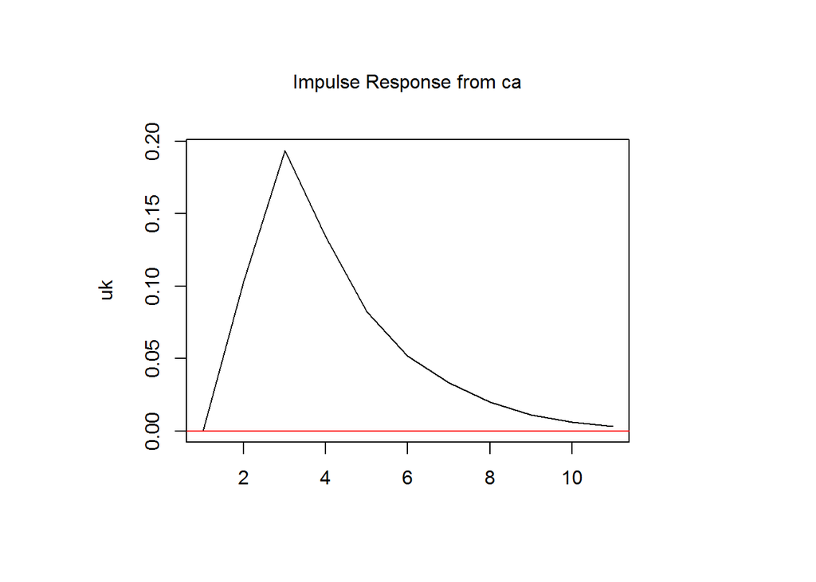

```r
irf.y21 <- irf(var.sim.est, impulse = 'ca',
              response = 'uk', n.ahead = 10,
              ortho = FALSE, cumulative = FALSE,
              boot = FALSE, seed = 12345)
plot(irf.y21)
```

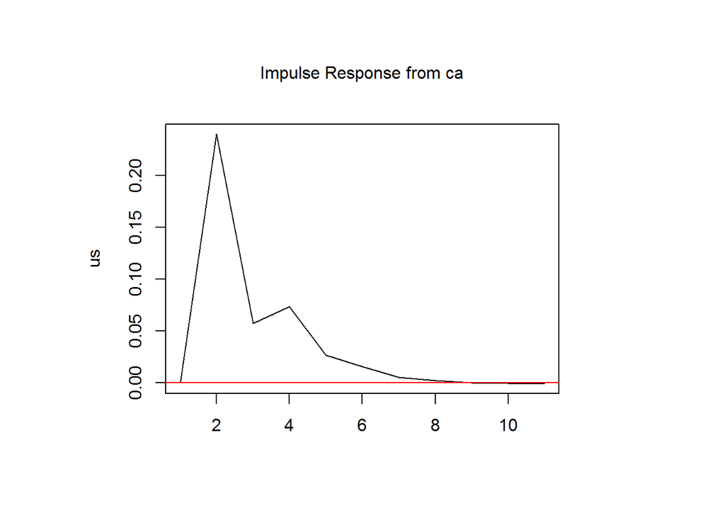

```r
irf.y23 <- irf(var.sim.est, impulse = 'ca',
              response = 'us', n.ahead = 10,
              ortho = FALSE, cumulative = FALSE,
              boot = FALSE, seed = 12345)
plot(irf.y23)
```

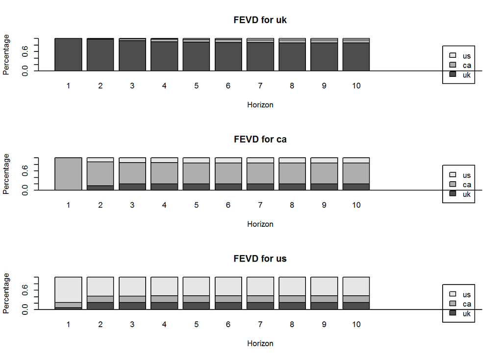

```r
## Pronostico descomosición de la varianza
fevd.var2 <- fevd(var.sim.est, n.ahead = 10)
plot(fevd.var2, addbars = 3)
```